# ST5226 Spatial Statistics: Tutorials 1 - 4

2022-10-03

## Tutorial 1

### Question 1: Hawker Centres in Singapore (`SpatialPoints`)

```r
# Loading Hawker Centre Data
hawkers <- readRDS("hawker.rds")
hw <- hawkers[[1]][-1]; str(hw[[1]])
```

```
## List of 12
##  $ ADDRESSBUILDINGNAME    : chr ""
##  $ ADDRESSFLOORNUMBER     : chr ""
##  $ ADDRESSPOSTALCODE      : chr "141001"
##  $ ADDRESSSTREETNAME      : chr "Commonwealth Drive"
##  $ ADDRESSUNITNUMBER      : chr ""
##  $ DESCRIPTION            : chr "HUP Standard Upgrading"
##  $ HYPERLINK              : chr ""
##  $ NAME                   : chr "Blks 1A/ 2A/ 3A Commonwealth Drive"
##  $ PHOTOURL               : chr ""
##  $ ADDRESSBLOCKHOUSENUMBER: chr "1A/2A/3A"
##  $ XY                     : chr "24055.5,31341.24"
##  $ ICON_NAME              : chr "HC icons_Opt 8.jpg"
```

```r
# Extracting Key Variables of Interest

col_extract <- function(x){
  ## ----
  # Input: Takes in one such hawker centre object (list)
  # Output: Returns a data frame with columns: post_code, street, X, Y
  ## ----
  post_code = x$ADDRESSPOSTALCODE
  street = x$ADDRESSSTREETNAME
  X_Y = as.numeric(strsplit(x$XY, ",")[[1]])
  X = X_Y[1]; Y = X_Y[2]

  result = c(post_code, street, X, Y)
  return(result)
}

# Testing Helper Function
col_extract(hw[[1]])
```

```
## [1] "141001"             "Commonwealth Drive" "24055.5"
## [4] "31341.24"
```

```r
# Applying Helper Function on Full Dataset
hawkers_mat = matrix(unlist(sapply(hw,col_extract)), ncol = 4, byrow = TRUE);
colnames(hawkers_mat) = c("post_code","street","X","Y")

hawkers_df = data.frame(hawkers_mat)
hawkers_df$X = as.numeric(hawkers_df$X); hawkers_df$Y = as.numeric(hawkers_df$Y)
str(hawkers_df)
```

```
## 'data.frame':    116 obs. of  4 variables:
##  $ post_code: chr  "141001" "730020" "641221" "161022" ...
##  $ street   : chr  "Commonwealth Drive" "Marsiling Lane" "Boon Lay Place" "Havelock Road" ...
##  $ X        : num  24056 21755 14588 27589 33756 ...
##  $ Y        : num  31341 47283 36374 30043 34298 ...
```

Next, we plot the hawker centres on the map of Singapore, distinguishing those in the North and South with different colours.

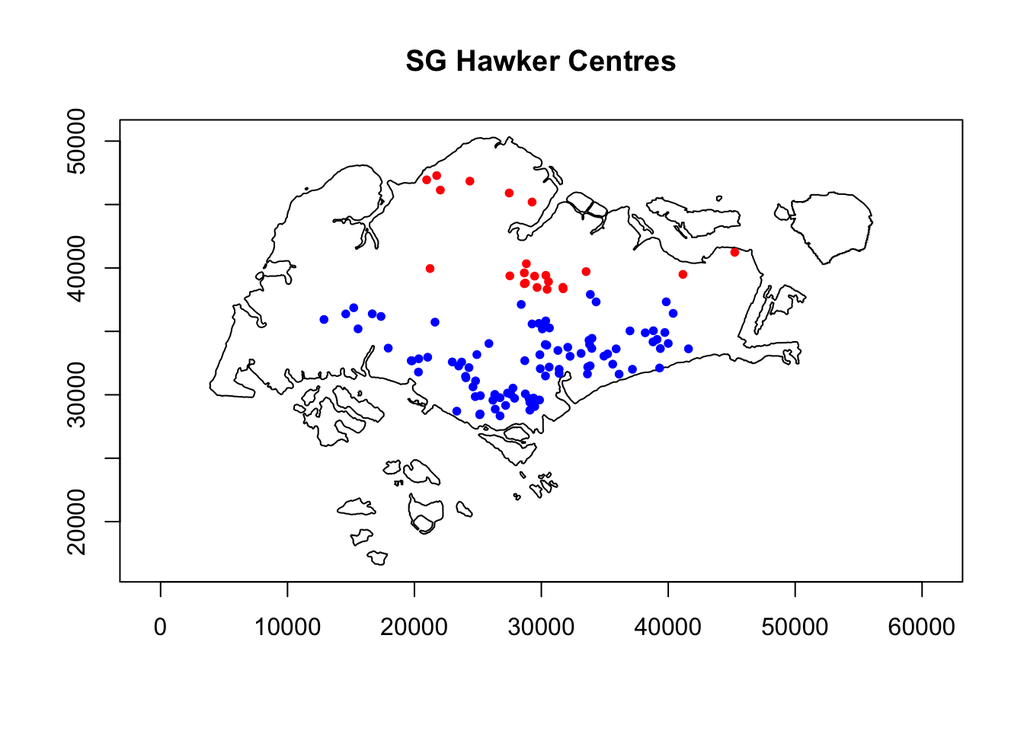

```r
library(sp)
sg <- readRDS("sg_boundary.rds") # Load SG boundary shape file
sgCRS = sg@proj4string

# Initialize SpatialPoints object using hawkers_df
hawkers_sp = SpatialPoints(hawkers_df[,3:4], proj4string = sgCRS)

# Want to classify SpatialPoints based on those in North vs South
# Note: coordinates(sg) gives us the centroid of the spatial polygon inside sg
sg_centroid_x = coordinates(sg)[1]; sg_centroid_y = coordinates(sg)[2]
sp_north = hawkers_sp[hawkers_sp$Y > sg_centroid_y]
sp_south = hawkers_sp[hawkers_sp$Y <= sg_centroid_y]

# Plot of Hawker Centre Locations in SG
plot(sg, axes = TRUE)
plot(sp_north, pch = 20, col = "red", add = TRUE)
plot(sp_south, pch = 20, col = "blue"  ,add = TRUE)
title("SG Hawker Centres")
```

### Question 2: Subzones in Singapore (`SpatialPolygons`)

Note: `subzones_spdf <- SpatialPolygonsDataFrame(subzones_sp,pop_data)` does not work because the row IDs do not match.

`SpatialPolygonsDataFrame` with default ID matching checks the data frame row names against the Polygons ID slots. They must then agree with each other, and be unique (no Polygons objects can share IDs); the data frame rows will be re-ordered if needed to match the Polygons IDs.

```r
rm(list=ls())

# Loading Singapore Sub-Zones
load("subzones_tutorial_1.rdt")
str(pop_data)
```

```
## 'data.frame':    310 obs. of  2 variables:
##  $ subzone: chr  "YUHUA" "CLEMENTI WOODS" "SENNETT" "PAYA LEBAR" ...
##  $ total  : num  NA 16230 4420 NA 0 ...
```

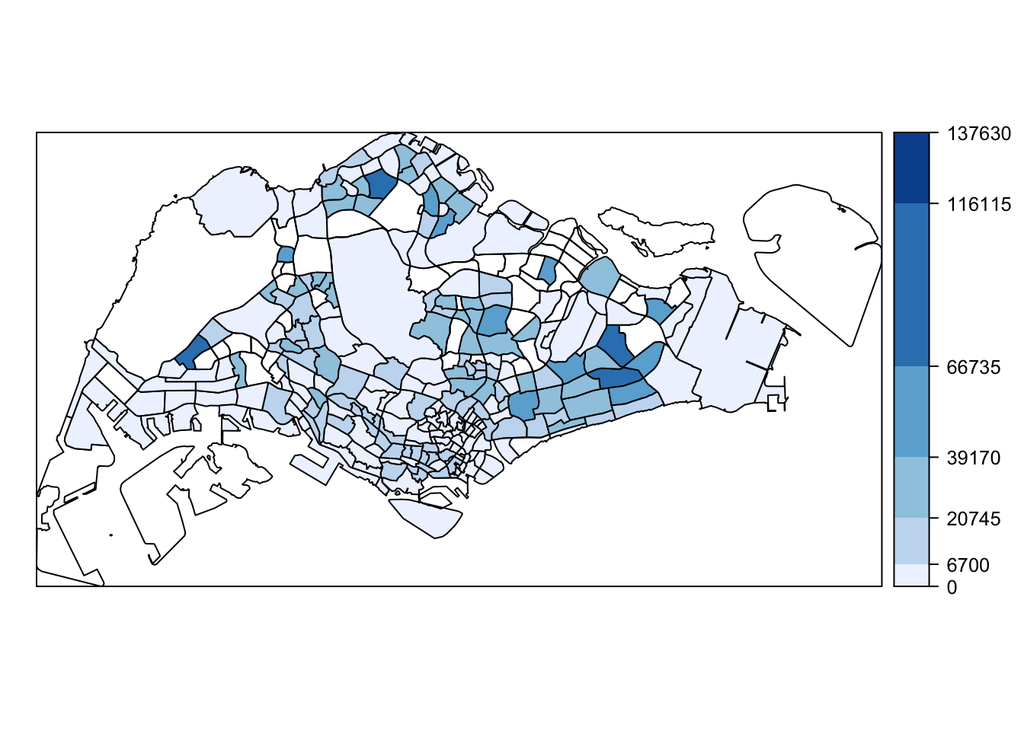

```r
# ID matching checks data frame ROW NAMES against Polygons ID slots
# Set row.names for pop_data df first:
row.names(pop_data) <- pop_data$subzone
# Initializing SpatialPolygonsDataFrame object
subzones_spdf <- SpatialPolygonsDataFrame(subzones_sp,pop_data)

# Display Plot of SubZones
library(RColorBrewer); library(classInt)

# Using Fisher Class Intervals
q6 <- classIntervals(subzones_spdf$total, n=6, style = "fisher")
spplot(subzones_spdf, "total", at=q6$brks,
       colorkey=list(labels=list(at=q6$brks)),
       col.regions=brewer.pal(6, "Blues"))
```

### Question 3: Fox Rabies Cases in Germany (`SpatialGridDataFrame`)

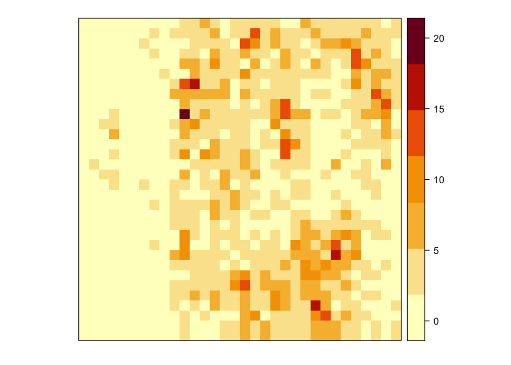

```r
rm(list=ls())

# Loading fox rabies case-matrix
fox_rabies <- readRDS("fox_rabies.rds"); colnames(fox_rabies) <- as.character(c(1:32))
grid_topo <- GridTopology(c(0,0), c(1,1), c(32,32)) # Initialize grid_topology
spat_grid <- SpatialGrid(grid_topo)

# Creating SpatialGridDataFrame
flat = as.vector(t(fox_rabies)) # Note we need to take transpose first, as R will read the matrix column-wise
sgdf_fox = SpatialGridDataFrame(spat_grid,data.frame(flat))

spplot(sgdf_fox, cuts = 6,
       col.regions = hcl.colors(12, "YlOrRd", rev = TRUE))
```

## Tutorial 2

### Mapping Smoothed Rates - Theory

### Question 2

Suppose that we have observed disease counts $Y_1,\dots,Y_N$ in $N$ areas, and we also know that the population in these regions $n_1,\dots,n_N$.

Let $f$ denote the probability mass function of $Y_i | \xi$, let $l_i$ denote the weighted log-likelihood associated with region $i$:

$$l_i(\xi) = \sum^{N}_{j=1} w_{ij}\log f(y_j|\xi)$$
Show that the value of $\xi$ that maximizes the weighted log-likelihood is

$$\hat\xi_i = \frac{\sum_{j=1}^{N}w_{ij}Y_j}{\sum_{j=1}^{N}w_{ij}n_j}$$

#### Solution:

The probability mass function is

$$f(y_j|\xi) = e^{-n_j\xi}\frac{(n_j\xi)^{y_j}}{y_j!}$$
Hence, the log-likelihood is given by

### Georgia Birth Data

The file `GHCD9.rds` contains a `SpatialPolygonsDataFrame` of 25 contiguous counties in Georgia. The data is from 1999, and contains the following columns:

- **CON:** County Name.
- **LB:** Number of Live Births of single infants.
- **LBW:** Number of Low Birth Weight infants. (A subset of above)
- **VLBW:** Number of Very Low Birth Weight infants. (A subset of above)

```r
rm(list=ls())

# Loading Geogia SpatialPolygonsDataFrame object
gc <- readRDS("GHCD9.rds")
str(gc@data)
```

```
## 'data.frame':    25 obs. of  6 variables:
##  $ CON     : Factor w/ 25 levels "Appling","Atkinson",..: 17 12 11 2 1 4 24 9 3 21 ...
##  $ LB      : int  238 666 99 164 257 124 492 127 143 228 ...
##  $ LBW     : int  28 66 10 12 23 8 46 8 12 11 ...
##  $ VLBW    : int  2 18 2 5 1 1 3 0 2 2 ...
##  $ Easting : num  344402 325675 334631 321340 374322 ...
##  $ Northing: num  3524050 3487195 3423797 3464443 3513589 ...
```

```r
# Compute rate of VLBW in each county
gc$r = gc$VLBW/gc$LB

# Choropleth map plot
library(RColorBrewer); library(classInt)

con_names = abbreviate(gc$CON)
# Names against abbreviations (As a reference table)
county_names = data.frame(matrix(c(as.character(gc$CON),con_names), ncol = 2))
colnames(county_names) = c("County","Abbrev")
head(county_names)
```

```
##       County Abbrev
## 1 Jeff Davis   JffD
## 2     Coffee   Coff
## 3     Clinch   Clnc
## 4   Atkinson   Atkn
## 5    Appling   Appl
## 6   Brantley   Brnt
```

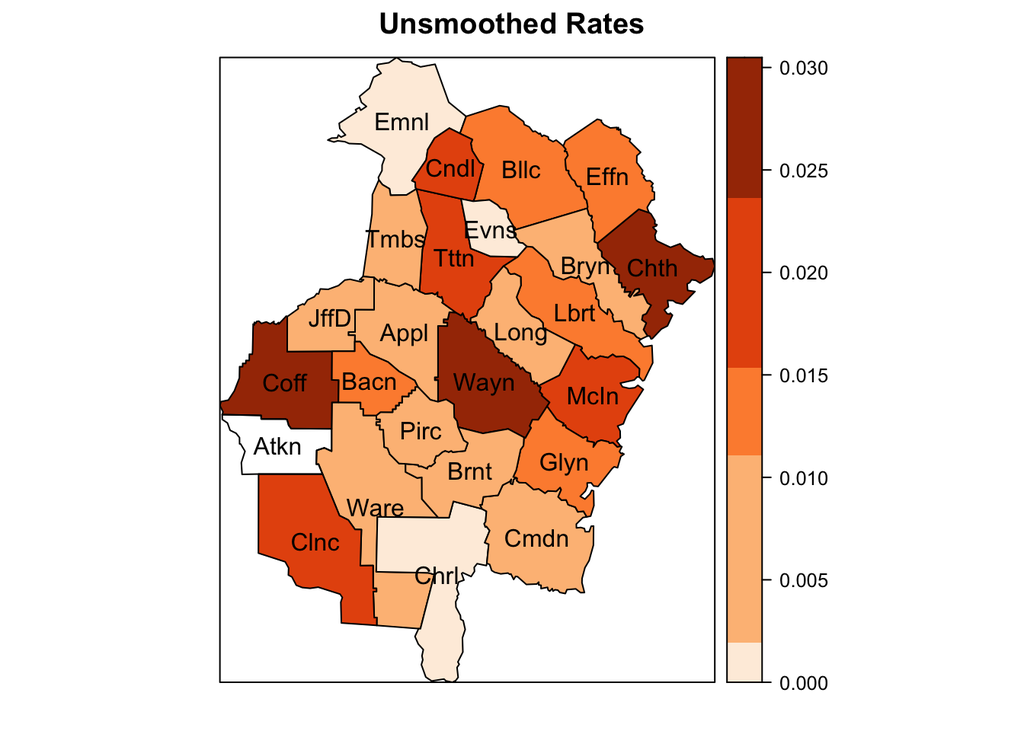

```r
# Generating Plot of Raw Rates
pal <- brewer.pal(n=5, "Oranges")
spplot(gc, "r", col.regions=pal, main="Unsmoothed Rates",
       at=classIntervals(gc$r, n=5, "fisher")$brks, # Using Natural Breaks
       sp.layout=list("sp.text", coordinates(gc), con_names)) # Overlay County names on plot
```

If we compare the abbreviated names to the original ones, we might conclude that counties Atkinson, Coffee, Wayne and Chatham have the highest rates, while Charlton, Evans and Emanuel have the lowest. However, we also have to inspect their LB values (effectively the $n_i$’s in this question).

If we do so, we can clearly see we are being impacted by the small number problem – there are regions with very small counts and small population sizes. Moreover the distribution of population sizes is quite skewed. Some smoothing is in order.

```r
slot(gc, "data")[c("Coffee", "Wayne", "Chatham",
"Charlton", "Emanuel", "Evans", "Atkinson"), # Filter out Counties of interest, compare LB and VLBW counts
c("CON", "LB", "VLBW")]
```

```
##               CON   LB VLBW
## Coffee     Coffee  666   18
## Wayne       Wayne  341   10
## Chatham   Chatham 3570  100
## Charlton Charlton  127    0
## Emanuel   Emanuel  308    0
## Evans       Evans  155    0
## Atkinson Atkinson  164    5
```

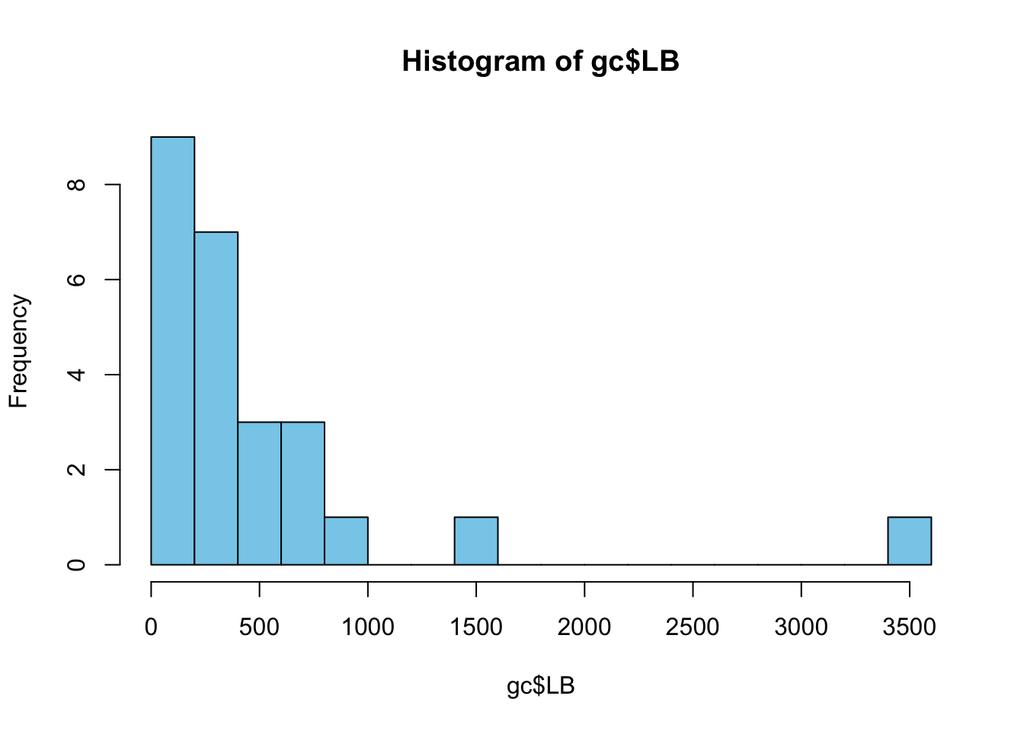

```r
# Plotting histogram of No. of Live Births
hist(gc$LB, breaks=20,col='skyblue')
```

#### Mapping Smoothed Rates

Implement the locally weighted average given by

$$\hat\xi_i = \frac{\sum_{j=1}^{N}w_{ij}Y_j}{\sum_{j=1}^{N}w_{ij}n_j}$$
where

$$w_ij =
\begin{cases}
1 \quad \text{if} \quad d_ij \leq D \\
0 \quad \text{if} \quad d_ij > D
\end{cases}$$
where $D = 60$ km.

**Note:** The function `spDists` (in package `sp`) can be used to compute pair-wise distances. For example if `gc` is the R object loaded from `GHCD9.rds`, then `SpDists(coordinates(gc),longlat=TRUE)` gives you the required pairwise distances between centroids of counties.

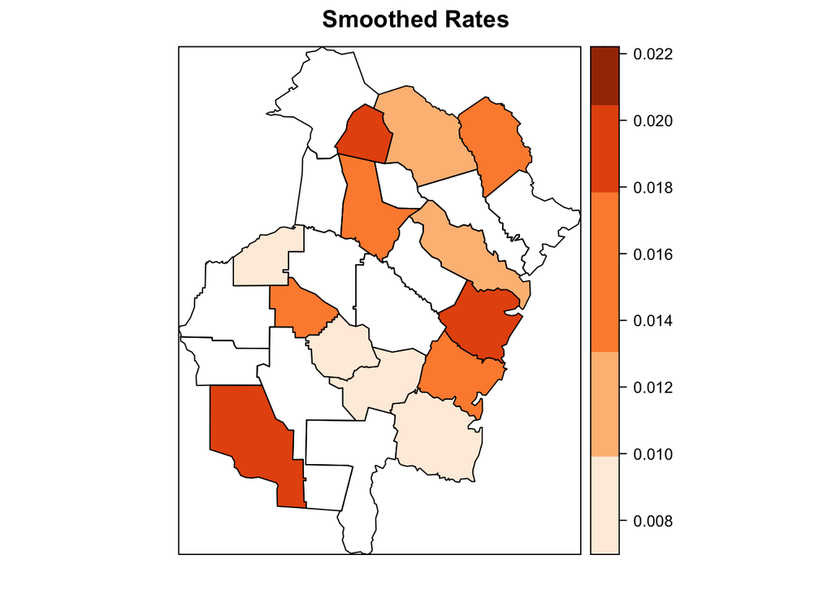

```r
# Using Method of Locally Weighted Averages

d_ij = spDists(coordinates(gc),longlat = TRUE) # pairwise distance (25 x 25 matrix) in km
w_ij = 1*(d_ij <= 60) # indicator weights (25 x 25 matrix)

# Note that we should use colSums, instead of rowSums
# R performs column-wise multiplication in w_ij*Y_j
Y_j = gc$VLBW; n_j = gc$LB
xi_hat = colSums(w_ij*Y_j)/colSums(w_ij*n_j); gc$xi_hat = xi_hat

# Generating plot using smoothed rates
spplot(gc, "r", col.regions=pal, main="Smoothed Rates",
       at=classIntervals(gc$xi_hat, n=5, "fisher")$brks) # Using Natural Breaks
```

## Tutorial 3

### Question 1: Quadrat Counts and Morisita Index

```r
# Quadrat Count Test (different grid size)
data(redwood)
library(spatstat)
quadrat.test(redwood,nx = 2) # p-value = 0.1781 > 0.05 (do not reject Null)
```

```
##
##  Chi-squared test of CSR using quadrat counts
##
## data:  redwood
## X2 = 6.5161, df = 3, p-value = 0.1781
## alternative hypothesis: two.sided
##
## Quadrats: 2 by 2 grid of tiles
```

```r
quadrat.test(redwood,nx = 3) # p-value = 0.007333 < 0.05 (reject)
```

```
##
##  Chi-squared test of CSR using quadrat counts
##
## data:  redwood
## X2 = 22.774, df = 8, p-value = 0.007333
## alternative hypothesis: two.sided
##
## Quadrats: 3 by 3 grid of tiles
```

```r
# Different conclusions for test at alpha = .05
# Conclusion depends on size of quadrats chosen
```

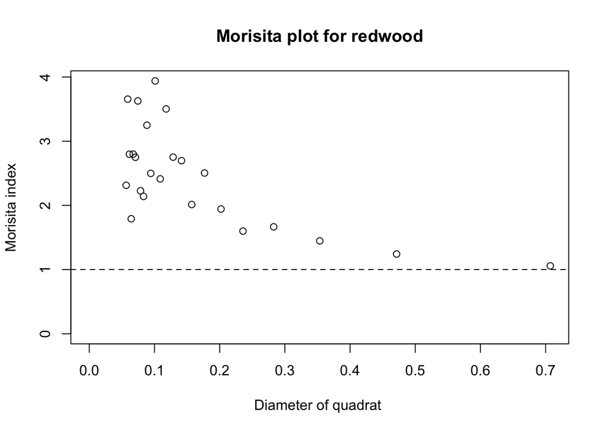

```r
# Morisita Index Plot
miplot(redwood) # For clustered data, index > 1
```

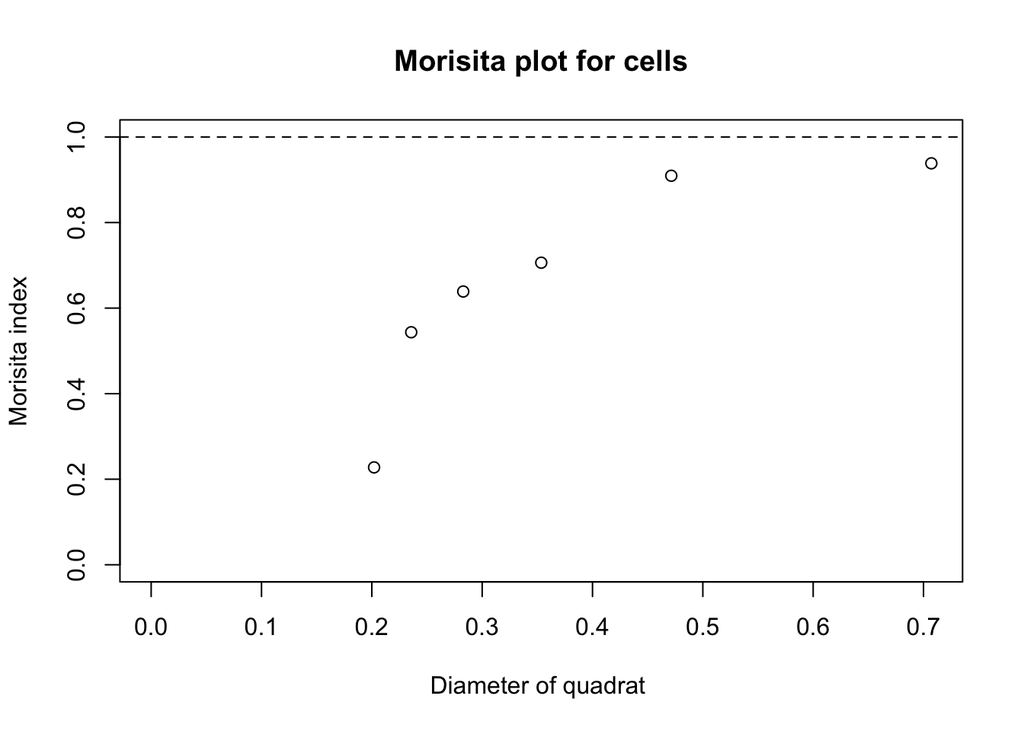

```r
data(cells); miplot(cells) # Regular point pattern, index < 1
```

A plot of Mq as a function of quadrat size gives information on whether a process is clustered, and on the sensitivity to the quadrat size. For clustered data, Morisita Index will be greater than 1, and for regular data, it will be less than 1.

### Question 3: Monte Carlo Test for HPP

```r
data(redwood) # loading redwood data

lambda = 62

Tvec = rep(0,100) # initialize empty vector of length 100
Tvec[1] = 2 * pi * lambda * sum(nndist(redwood)^2) # compute test statistic from obs data
set.seed(11)

# Simulate s = 99 datasets under Null
for (ii in 2:100){
  pp1 <- rpoispp(lambda) # Generating 62 random uniform points (can use rpoispp or runifpoint)
  Tvec[ii] = 2 * pi * lambda * sum(nndist(pp1)^2)
}

# Compute Monte-Carlo p-value
2* rank(Tvec)[1]/100 # 0.02 < alpha = .05
```

```
## [1] 0.02
```

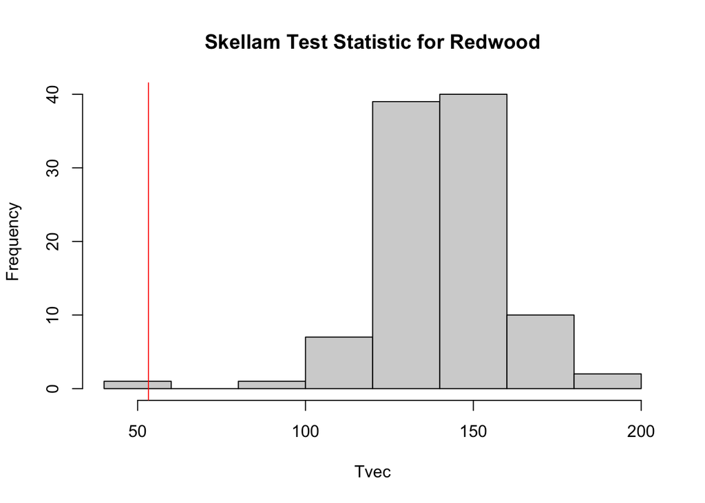

```r
# i.e. reject Null

# Histogram of Simulated results and Computed Test Statistic
hist(Tvec, main = "Skellam Test Statistic for Redwood")
abline(v=Tvec[1], col = "red")
```

Comments: The histogram shows that our observed test statistic is way out in the tail ofthe histogram generated under CSR. This signifies that our data do not agree well with the null hypothesis of CSR. The data return a very small p-value. As a reference, consider the japanese pines data, and perform the same test.

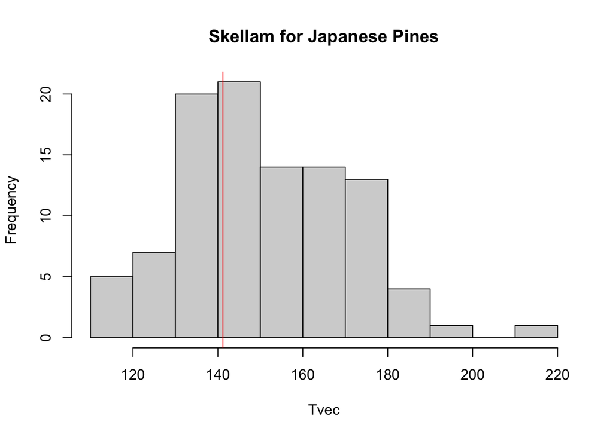

```r
# Test with Japanese Pines
Tvec <- rep(0, 100)
Tvec[1] <- 2 * pi * 65 * sum(nndist(japanesepines)^2)
set.seed(11)
for(ii in 2:100) {
  pp1 <- runifpoint(65)
  Tvec[ii] <- 2 * pi * 65 * sum(nndist(pp1)^2)
}
# p-value:
hist(Tvec, main="Skellam for Japanese Pines")
abline(v=Tvec[1], col='red')
```

### Question 4: Maple Tress in Michigan

From the plot alone, we observe that the process does not appear to have constant intensity.

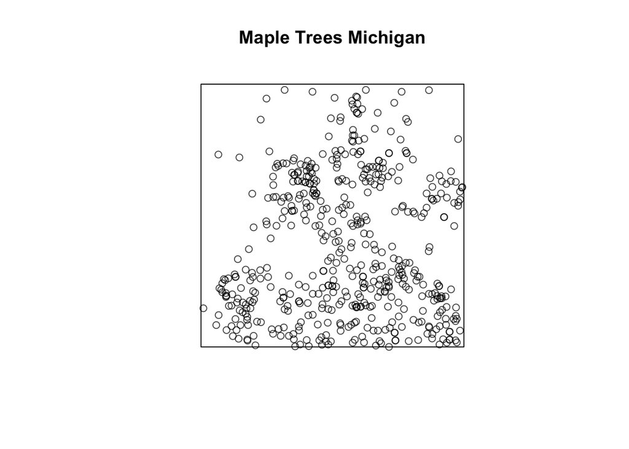

```r
maple <- readRDS("lansing_maple.rds")
library(spatstat)

## Preliminary Analysis of Point Pattern (EDA)

plot(maple, main ="Maple Trees Michigan")
```

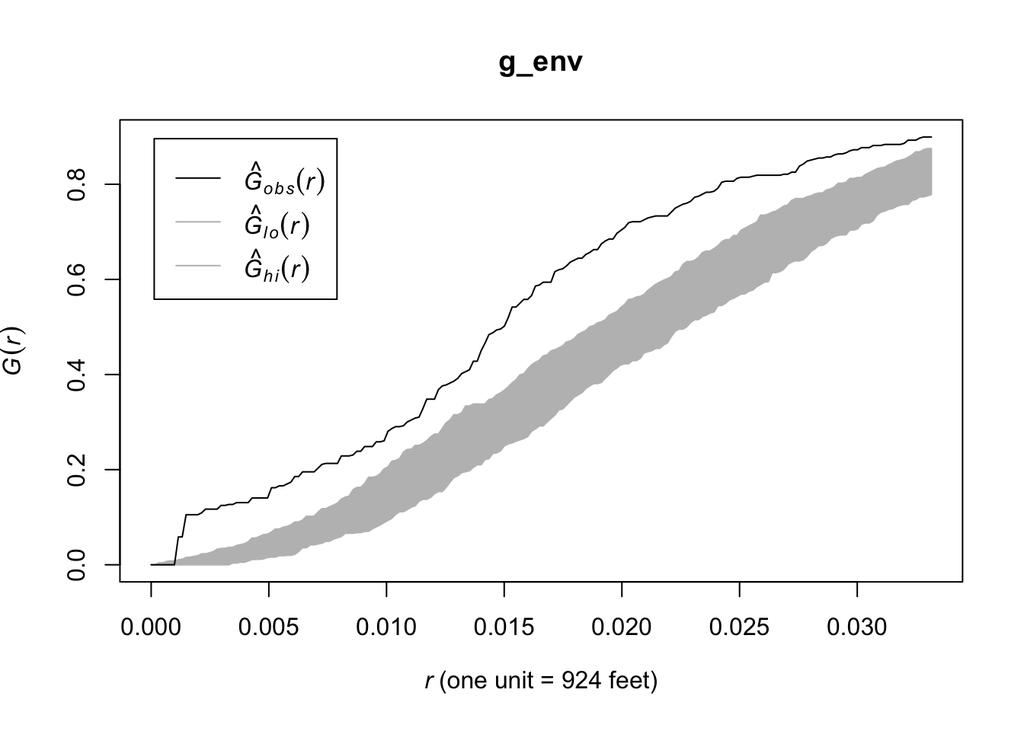

```r
# Consider G envelope plot at significance level = 4 %
set.seed(1009)
g_env <- envelope(maple, Gest, nrank = 2, nsim = 99, verbose = FALSE)
plot(g_env, obs~r) # G_obs lies above the envelope
```

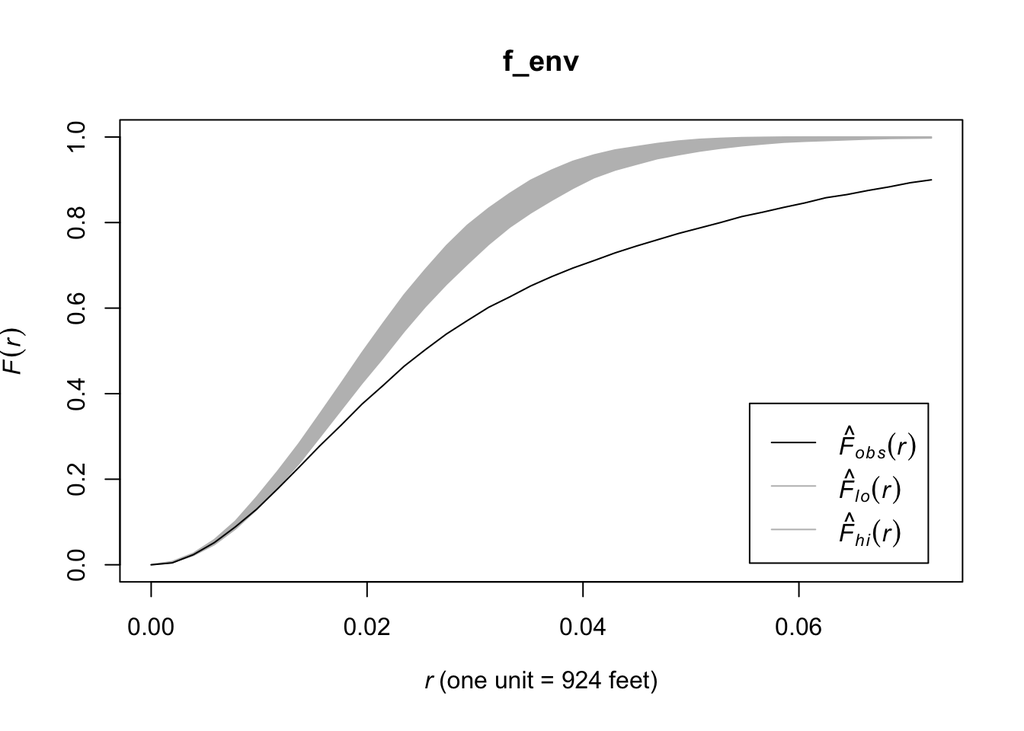

```r
# reject CSR, plot provides an indication of clustering

# F plot leads to the same conclusion
set.seed(1010)
f_env <- envelope(maple, Fest, nrank = 2, nsim = 99, verbose = FALSE)
plot(f_env, obs~r)
```

Both plots clearly show that the process has points closer together than a CSR process. The G function, which plots the probability that the nearest neighbor distances are less than a specified value, is consistently higher than the envelope generated by CSR.

The F function, which computes the probability that the distance from a randomly sampled point is less than a specified value, is consistently lower than the envelope generated by CSR. In other words, there is more empty space than CSR. The empty space is caused by points clustering together.

*Note:* Inconclusive if clustering is due to non-constant intensity function or interaction between points.

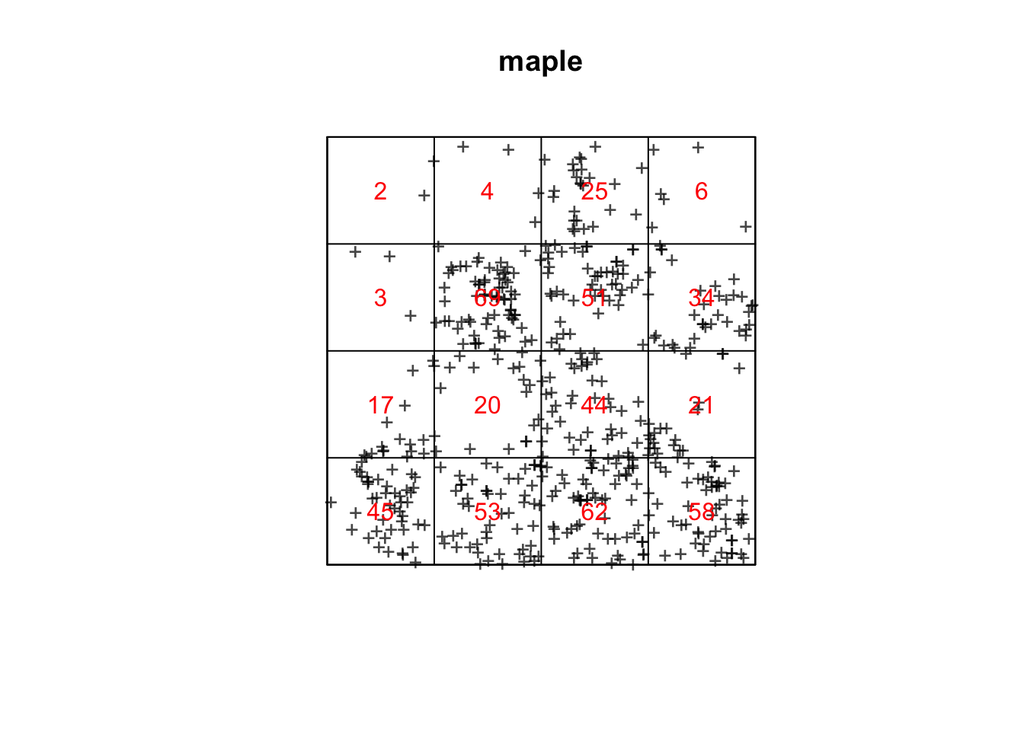

```r
# Consider Quadrat Test (Pearson Chi-Sq Goodness of Fit)
qm <- quadratcount(maple,nx = 4)
plot(maple,pch = "+")
plot(qm, add = TRUE, col = "red")
```

```r
quadrat.test(maple, nx = 4) # reject H_0 (of CSR)
```

```
##
##  Chi-squared test of CSR using quadrat counts
##
## data:  maple
## X2 = 242.92, df = 15, p-value < 2.2e-16
## alternative hypothesis: two.sided
##
## Quadrats: 4 by 4 grid of tiles
```

Quadrat test will reject the null hypothesis of CSR for almost all choices of grids. It is clear we do not have CSR, but exactly how it is being violated is not clear.

## Tutorial 4

### Graves Data

Research question is whether the spatial pattern of graves with affected teeth is the same as the spatial pattern of graves with unaffected teeth.

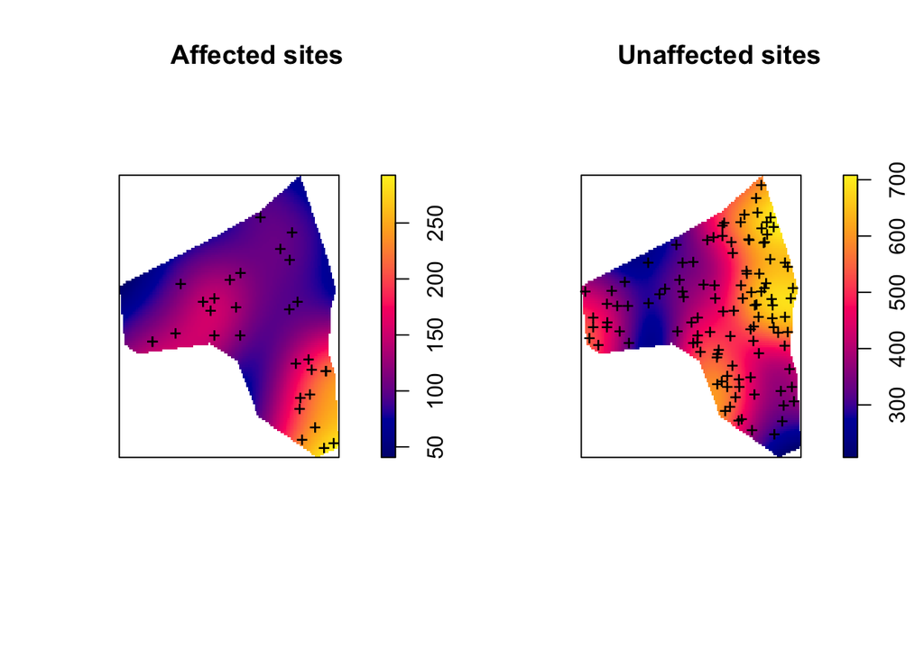

```r
load("grave.rdt")

# Nonparametrically estimate intensity function of each of the two grave types
## Using bw.scott bandwidth for spatial trend analysis (large sigma, greater smoothing)

opar <- par(mfrow=c(1,2))
plot(density(affected, bw.scott(affected)), main="Affected sites")
plot(affected, add=TRUE, pch='+')
plot(density(unaffected, bw.scott(unaffected)), main="Unaffected sites")
plot(unaffected, add=TRUE, pch='+')
```

```r
par(opar)

# High intensity regions for affected sites and unaffected sides do not coincide
```

The intensity function for the affected sites appears to be bimodal. The intensity function for the unaffected sites appears to have several modes. However, the modes do not appear in the same regions for the two processes. Neither process is suggestive of a HPP. In addition, the range of intensity values is much larger for the unaffected sites.

```r
# Next, to fit an IPP to each process
## Using trend functions up to order 2 (In this case, we consider constant, linear, quadratic model)

mod_aff_0 <- ppm(affected, ~1); mod_aff_0
```

```
## Stationary Poisson process
## Intensity: 119.683
##             Estimate      S.E.  CI95.lo  CI95.hi Ztest     Zval
## log(lambda) 4.784847 0.1825742 4.427008 5.142686   *** 26.20768
```

```r
mod_aff_1 <- ppm(affected, ~x+y); mod_aff_1 # Note that Zval shows terms are not significant
```

```
## Nonstationary Poisson process
##
## Log intensity:  ~x + y
##
## Fitted trend coefficients:
## (Intercept)           x           y
##   5.5628955   0.6650742  -2.0384607
##
##               Estimate     S.E.   CI95.lo   CI95.hi Ztest       Zval
## (Intercept)  5.5628955 1.502431  2.618184 8.5076069   ***  3.7025954
## x            0.6650742 1.292094 -1.867384 3.1975328        0.5147257
## y           -2.0384607 1.138049 -4.268996 0.1920747       -1.7911886
```

```r
mod_aff_2 <- ppm(affected, ~polynom(x,y,2)); mod_aff_2 # higher order terms not significant
```

```
## Nonstationary Poisson process
##
## Log intensity:  ~x + y + I(x^2) + I(x * y) + I(y^2)
##
## Fitted trend coefficients:
## (Intercept)           x           y      I(x^2)    I(x * y)      I(y^2)
##   -1.739713    9.703558    8.214736   -1.793467   -9.234060   -1.511485
##
##              Estimate      S.E.   CI95.lo  CI95.hi Ztest       Zval
## (Intercept) -1.739713 11.724788 -24.71987 21.24045       -0.1483790
## x            9.703558 17.836971 -25.25626 44.66338        0.5440138
## y            8.214736 17.097415 -25.29558 41.72505        0.4804665
## I(x^2)      -1.793467  8.491994 -18.43747 14.85054       -0.2111950
## I(x * y)    -9.234060 12.647975 -34.02363 15.55551       -0.7300821
## I(y^2)      -1.511485  6.859627 -14.95611 11.93314       -0.2203452
```

```r
AIC(mod_aff_0)
```

```
## [1] -225.0908
```

```r
AIC(mod_aff_1) # smallest AIC (model with trend order 1 is best fit)
```

```
## [1] -225.6738
```

```r
AIC(mod_aff_2)
```

```
## [1] -220.2252
```

```r
# Repeat for Unaffected graves data
mod_unaff_0 <- ppm(unaffected, ~1); mod_unaff_0
```

```
## Stationary Poisson process
## Intensity: 450.806
##             Estimate       S.E.  CI95.lo  CI95.hi Ztest     Zval
## log(lambda) 6.111037 0.09407209 5.926659 6.295415   *** 64.96122
```

```r
mod_unaff_1 <- ppm(unaffected, ~x+y); mod_unaff_1
```

```
## Nonstationary Poisson process
##
## Log intensity:  ~x + y
##
## Fitted trend coefficients:
## (Intercept)           x           y
##   4.7986708   1.1126814   0.5780727
##
##              Estimate      S.E.    CI95.lo  CI95.hi Ztest     Zval
## (Intercept) 4.7986708 0.7228331  3.3819439 6.215398   *** 6.638698
## x           1.1126814 0.6488597 -0.1590602 2.384423       1.714826
## y           0.5780727 0.5607964 -0.5210681 1.677213       1.030807
```

```r
mod_unaff_2 <- ppm(unaffected, ~polynom(x,y,2)); mod_unaff_2
```

```
## Nonstationary Poisson process
##
## Log intensity:  ~x + y + I(x^2) + I(x * y) + I(y^2)
##
## Fitted trend coefficients:
## (Intercept)           x           y      I(x^2)    I(x * y)      I(y^2)
##   15.214201  -14.002460  -10.981007    3.053603   15.409452   -1.701428
##
##               Estimate     S.E.    CI95.lo    CI95.hi Ztest       Zval
## (Intercept)  15.214201 4.934320   5.543112 24.8852906    **  3.0833431
## x           -14.002460 7.436253 -28.577248  0.5723289       -1.8829993
## y           -10.981007 7.785287 -26.239889  4.2778760       -1.4104819
## I(x^2)        3.053603 4.061053  -4.905915 11.0131207        0.7519238
## I(x * y)     15.409452 6.317037   3.028287 27.7906160     *  2.4393481
## I(y^2)       -1.701428 3.245228  -8.061958  4.6591014       -0.5242863
```

```r
AIC(mod_unaff_0)
```

```
## [1] -1153.094
```

```r
AIC(mod_unaff_1)
```

```
## [1] -1152.703
```

```r
AIC(mod_unaff_2) # smallest AIC (model with trend order 2 is best fit)
```

```
## [1] -1154.5
```

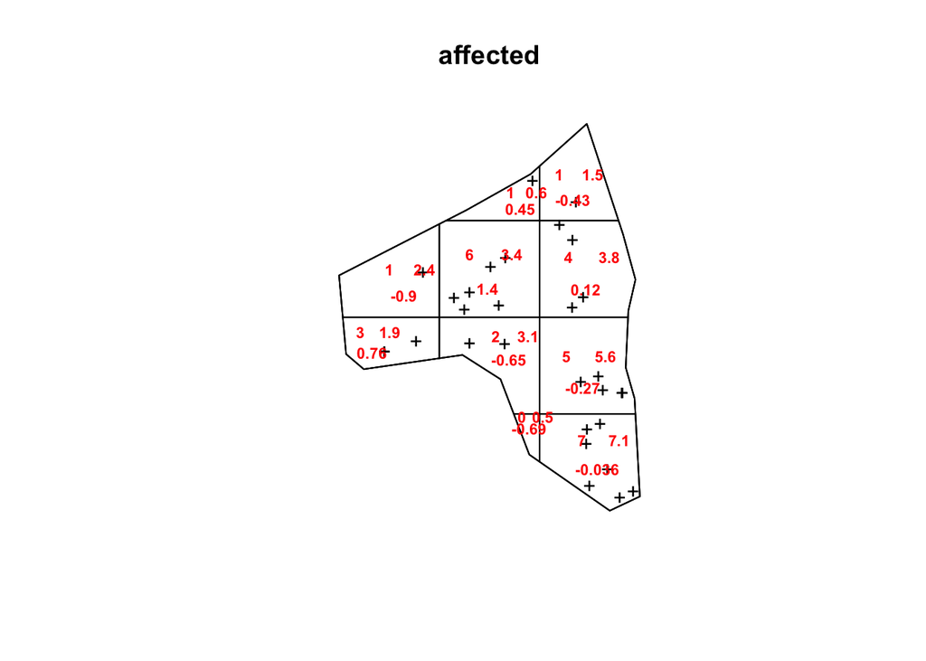

```r
set.seed(11)
# Quadrat Count Test to assess Goodness of Fit
## Chi-Sq approximation inaccurate due to small expected cell counts, use Monte Carlo instead
Q1 <- quadrat.test(mod_aff_1, nx = 3, ny = 4, method = "MonteCarlo")
plot(affected, main = "affected", pch = "+")
plot(Q1, add = TRUE, col = "red", textargs=list(cex=0.7, font=2)) # residuals give an idea of the fit
```

```r
Q1
```

```
##
##  Conditional Monte Carlo test of fitted Poisson model 'mod_aff_1' using
##  quadrat counts
##  Test statistic: Pearson X2 statistic
##
## data:  data from mod_aff_1
## X2 = 4.8312, = NA, p-value = 0.316
## alternative hypothesis: two.sided
##
## Quadrats: 10 tiles (irregular windows)
```

```r
# little evidence against the null, do not reject IPP
```

[figure not shown]

```r
Q2 <- quadrat.test(mod_unaff_2, nx = 3, ny = 4, method = "MonteCarlo")
plot(affected, main = "unaffected", pch = "+")
plot(Q2, add = TRUE, col = "red", textargs=list(cex=0.7, font=2))
```

```r
Q2 # do not reject IPP
```

```
##
##  Conditional Monte Carlo test of fitted Poisson model 'mod_unaff_2'
##  using quadrat counts
##  Test statistic: Pearson X2 statistic
##
## data:  data from mod_unaff_2
## X2 = 5.814, = NA, p-value = 0.51
## alternative hypothesis: two.sided
##
## Quadrats: 10 tiles (irregular windows)
```

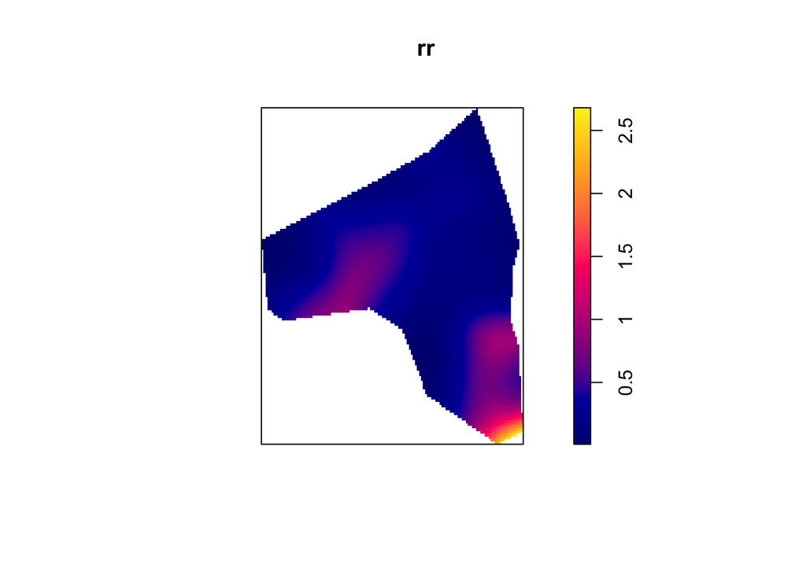

```r
# Estimating relative risk
rr <- relrisk(grave,relative = TRUE, casecontrol = TRUE, case = "affected")
plot(rr)
```